# 한국판 Kevin Bacon 놀이

Dr.Kevin

2/20/2018

Kevin Bacon의 여섯 다리(Six Degrees of Kevin Bacon)는 어떤 배우와 Kevin Bacon까지 최단의 연결 고리를 만드는 놀이입니다. 같은 영화에 출연했다면 연결고리는 1이 되고, 같은 영화에 출연한 어떤 배우와 다른 영화에서 함께 출연한 배우라면 2가 되는 식이죠. Kevin Bacon이 다작(多作)하는 배우라는 인식 때문에 생겨난 놀이라고 할 수 있습니다.[^1]

한국영화에 출연한 배우들을 대상으로 배우 간 최단거리를 구한 후 평균을 내서 누가 가장 많은 배우들과 직간접적으로 연결되어 있는지 확인해보고자 합니다.

이번 포스팅은 총 3단계로 나누어 정리하였습니다.

- 1단계는 데이터 수집 방법을 담았습니다. R로 웹크롤러를 만들어 이번 프로젝트에서 필요로 하는 영화 목록과 그 영화에 출연한 배우 목록의 수집방법을 간략하게 설명합니다.
- 2단계는 수집된 데이터로 전처리하는 방법을 설명합니다. 두 목록을 하나의 데이터 프레임으로 합치고 **영화-배우 행렬**로 변환한 후, 다시 **배우-배우 행렬**을 생성하여 함께 출연한 배우 데이터셋을 완성합니다.
- 3단계는 **배우-배우 행렬**로 방향성 없는 무향 `graph` 객체를 만든 후, 배우 간 최단거리를 계산하여 평균을 내는 방식으로 **한국판 Kevin Bacon**을 찾습니다. 아울러 간단한 네트워크 그래프 예제도 소개합니다.

```r
# 작업일자 지정
wdate <- format(x = Sys.Date(), '%Y%m%d')

# 한글 폰트 지정
par(family = 'NanumGothic')
```

## 1단계 : 웹데이터 수집

이번 프로젝트를 위해 R로 웹크롤러를 만들어 [네이버 영화 사이트](http://movie.naver.com)에 등록된 웹데이터를 수집하였습니다. 제가 만든 웹크롤러는 GitHub에 올렸습니다.[^2]

수집한 데이터는 총 4가지입니다. (기준일자 : 2018년 2월 17일)

1. 한국영화 27,121편에 대한 요약정보 (korean_movie_list_20180217.RDS)
2. 영화별 출연 배우 목록 (korean_movie_actor_20180217.RDS)
3. 영화별 평점 목록 (korean_movie_score_20180217.RDS)
4. 영화별 리뷰 목록 (korean_movie_review_20180217.RDS)

이 중에서 한국영화 요약정보와 출연 배우 목록 데이터만 사용할 예정이며, 나머지 데이터는 다른 프로젝트를 위해 미리 수집한 것입니다. RDS 형태로 저장했으므로 GitHub에서 내려받은 후 `readRDS()`로 읽어오면 됩니다.[^3]

## 2단계 : 데이터 전처리

1. 두 개의 RDS 파일을 `readRDS()`로 각각 읽어온 후, 하나의 데이터 프레임(`wdf`)으로 병합합니다.
2. `wdf`로부터 각 영화별 출연 배우수를 계산하고, 상위 20편의 목록을 확인합니다.
3. 마찬가지로 각 배우별 출연 영화수를 계산하고, 상위 20명의 목록을 확인합니다.
4. 히스토그램과 도수분포표로 간단하게 시각화합니다.
5. `wdf`에서 출연한 배우수가 2명 이상인 영화 및 출연한 영화수가 5편 이상인 배우만 남깁니다.
6. **영화-배우 행렬**로 변환한 다음 열 이름을 배우 이름으로 변경합니다.
7. 마지막으로 **배우-배우 행렬**을 만든 후, 합계가 0인 행의 위치를 찾아 삭제합니다.

이제 위 과정을 하나씩 실행해보겠습니다.

### 2-1. 데이터 읽고, 하나의 데이터 프레임으로 병합하기

```r
# 필요 패키지를 불러옵니다.
library(dplyr)
library(ggplot2)
library(reshape2)
```

```r
# 영화 데이터를 읽습니다.
movieList <- readRDS(file = './data/korean_movie_list_20180217.RDS')

# 영화 데이터의 구조를 확인합니다.
str(movieList)
```

```
## 'data.frame':    27121 obs. of  8 variables:
##  $ title: chr  "0.5" "0.6˚의 재앙 (The Disaster 0.6˚)" "0.7" "0.7%의 삶" ...
##  $ mlink: chr  "/movie/bi/mi/basic.nhn?code=68831" "/movie/bi/mi/basic.nhn?code=46851" "/movie/bi/mi/basic.nhn?code=48065" "/movie/bi/mi/basic.nhn?code=99481" ...
##  $ mcode: chr  "68831" "46851" "48065" "99481" ...
##  $ myear: chr  "2006" "2005" "2001" "2012" ...
##  $ oyear: chr  NA NA NA NA ...
##  $ genre: chr  NA "다큐멘터리" NA "다큐멘터리" ...
##  $ formt: chr  NA NA "단편영화" "단편영화" ...
##  $ grade: chr  "NR" NA NA NA ...
```

```r
# 영화 데이터를 미리보기 합니다.
head(movieList)
```

```
##                                            title
## 1                                            0.5
## 2                0.6˚의 재앙 (The Disaster 0.6˚)
## 3                                            0.7
## 4                                      0.7%의 삶
## 5                                           0000
## 6 007 수퍼맨의 귀향 (The Return of 007 Superman)
##                                mlink  mcode myear oyear      genre
## 1  /movie/bi/mi/basic.nhn?code=68831  68831  2006  <NA>       <NA>
## 2  /movie/bi/mi/basic.nhn?code=46851  46851  2005  <NA> 다큐멘터리
## 3  /movie/bi/mi/basic.nhn?code=48065  48065  2001  <NA>       <NA>
## 4  /movie/bi/mi/basic.nhn?code=99481  99481  2012  <NA> 다큐멘터리
## 5 /movie/bi/mi/basic.nhn?code=147380 147380  2015  <NA>       <NA>
## 6 /movie/bi/mi/basic.nhn?code=116885 116885  2007  <NA> 다큐멘터리
##      formt       grade
## 1     <NA>          NR
## 2     <NA>        <NA>
## 3 단편영화        <NA>
## 4 단편영화        <NA>
## 5 단편영화 15세 관람가
## 6     <NA>        <NA>
```

```r
# 영화 형식별 빈도수를 확인합니다.
table(movieList$formt, useNA = 'ifany')
```

```
##
##     TV시리즈       TV영화     단편영화   뮤직비디오   비디오영화
##         4000          119        11684           42          649
##     성인영화 옴니버스영화     웹드라마       웹무비         <NA>
##           94          172          157           12        10192
```

```r
# 영화 장르별 빈도수를 확인합니다.
table(movieList$genre, useNA = 'ifany')
```

```
##
##               SF             가족         공연실황             공포
##               74              167               63              212
##           느와르       다큐멘터리           드라마 멜로/애정/로맨스
##               18             1998             6320              975
##             모험             무협           뮤지컬         미스터리
##               16                3                9              108
##             범죄       블랙코미디             서사         서스펜스
##              157                4                5                5
##           스릴러             실험       애니메이션             액션
##              216              229             2085              374
##             에로             전쟁           코미디           판타지
##              153               58              773              113
##             <NA>
##            12986
```

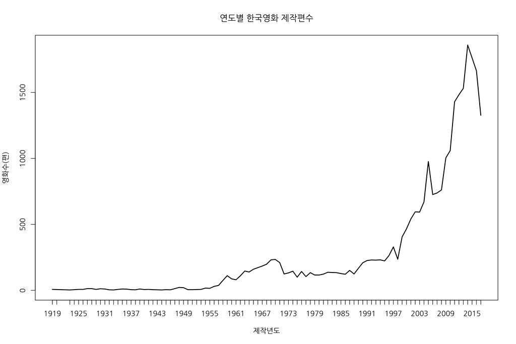

```r
# 제작년도별 영화편수를 확인하고 간단한 선그래프를 그려봅니다.
mvYearTbl <- table(movieList$myear, exclude = c(NA, '2018', '2020'))
plot(x = mvYearTbl, type = 'l',
     xlab = '제작년도', ylab = '영화수(편)',
     main = '연도별 한국영화 제작편수')
```

영화 데이터 컬럼 중 형식과 장르에 `NA`가 상당히 많아 정보가 충분하지 않다는 것을 확인할 수 있습니다. 아울러 제작년도도 일부 잘못 기입된 것도 있습니다.

```r
# 영화별 출연 배우 데이터를 읽습니다.
actorList <- readRDS(file = './data/korean_movie_actor_20180217.RDS')

# 배우 데이터의 구조를 확인합니다.
str(actorList)
```

```
## 'data.frame':    110630 obs. of  4 variables:
##  $ mcode: chr  "147380" "147380" "147380" "147380" ...
##  $ aname: chr  "박현수" "이보리" "전혜원" "이민지" ...
##  $ alink: chr  "/movie/bi/pi/basic.nhn?code=381876" "/movie/bi/pi/basic.nhn?code=363129" "/movie/bi/pi/basic.nhn?code=406889" "/movie/bi/pi/basic.nhn?code=389265" ...
##  $ acode: chr  "381876" "363129" "406889" "389265" ...
```

```r
# 배우 데이터를 미리보기 합니다.
head(actorList)
```

```
##    mcode  aname                              alink  acode
## 1 147380 박현수 /movie/bi/pi/basic.nhn?code=381876 381876
## 2 147380 이보리 /movie/bi/pi/basic.nhn?code=363129 363129
## 3 147380 전혜원 /movie/bi/pi/basic.nhn?code=406889 406889
## 4 147380 이민지 /movie/bi/pi/basic.nhn?code=389265 389265
## 5 147380 공예림 /movie/bi/pi/basic.nhn?code=389266 389266
## 6  41338 심형래   /movie/bi/pi/basic.nhn?code=1841   1841
```

```r
# 두 데이터프레임을 하나로 병합합니다.
wdf <- merge(x = movieList[, c('title', 'mcode', 'myear', 'genre', 'formt', 'grade')],
             y = actorList[, c('mcode', 'aname', 'acode')],
             by = 'mcode',
             all.x = T)
```

### 2-2. 영화별 출연 배우수 계산

```r
# 영화별 출연 배우수 벡터를 만듭니다.
numActors <- wdf %>%
  select(c('mcode', 'acode')) %>%
  na.omit() %>%
  group_by(mcode) %>%
  summarize(actorCnt = n())

# wdf에 병합하고 벡터는 삭제합니다.
wdf <- merge(x = wdf, y = numActors, by = 'mcode', all.x = T)
rm(numActors)

# 영화별 출연 배우 빈도수를 확인합니다.
table(wdf$actorCnt, useNA = 'ifany')
```

```
##
##     1     2     3     4     5     6     7     8     9    10    11    12
##  1628  4630  8805 10480  5870  5286  4711  4680  4761  5110  4202  4392
##    13    14    15    16    17    18    19    20    21    22    23    24
##  4069  4354  3645  3904  3247  2826  2660  2320  2037  1870  1196  1176
##    25    26    27    28    29    30    31    32    33    34    35    36
##  1175   676   891   700   667   690   310   480   462   646   455   324
##    37    38    39    40    41    42    43    44    45    46    47    48
##   333   342   195   320   123   168   129   176   135   138    94   144
##    49    50    51    52    53    54    55    56    57    58    59    60
##   196    50   153    52    53    54   110    56    57   174   118    60
##    61    62    64    66    67    69    76    79    80    82    87    96
##   122    62   128    66    67    69    76    79    80    82    87   192
##   101   107   117   129   134   167  <NA>
##   101   107   117   129   134   167 10169
```

```r
# NA 행을 삭제합니다. 출연한 배우 데이터가 없는 영화들입니다.
wdf <- wdf[is.na(wdf$actorCnt) == FALSE, ]

# 가장 많은 배우가 출연한 영화 상위 20편의 목록을 확인합니다.
wdf %>%
  select(c('title', 'actorCnt')) %>%
  na.omit() %>%
  unique() %>%
  arrange(desc(actorCnt)) %>%
  head(n = 20L)
```

```
##                                                                  title
## 1                                                           개그콘서트
## 2                                                            용의 눈물
## 3                                                     전설의 고향 1996
## 4                                                     전설의 고향 1997
## 5  전설의 고향 - 2009년 시리즈 (Hometown Of Legend - Year 2009 Series)
## 6                                                                 토지
## 7                                        신세대 보고서 어른들은 몰라요
## 8                                                        주몽 (Jumong)
## 9                                                            폭소 클럽
## 10                                                              웃찾사
## 11                                                              자명고
## 12                                         박하사탕 (Peppermint Candy)
## 13                                                           대왕의 꿈
## 14                                                       티라노의 발톱
```

[output cut: 27 more lines]

개그콘서트가 가장 많은 배우들이 출연한 영화이군요.

### 2-3. 배우별 출연 영화수 계산

```r
# 배우별 출연 영화수 벡터를 만듭니다.
numMovies <- wdf %>%
  select(c('mcode', 'acode')) %>%
  na.omit() %>%
  group_by(acode) %>%
  summarize(movieCnt = n())

# wdf에 병합하고 벡터는 삭제합니다.
wdf <- merge(x = wdf, y = numMovies, by = 'acode', all.x = T)
rm(numMovies)

# 배우별 출연 영화수 빈도수를 확인합니다.
table(wdf$movieCnt, useNA = 'ifany')
```

```
##
##     1     2     3     4     5     6     7     8     9    10    11    12
## 16362  6780  4860  3892  3270  2940  2520  2360  2214  2000  1881  1980
##    13    14    15    16    17    18    19    20    21    22    23    24
##  1534  2002  1455  1664  1751  1494  1653  1580  1323  1188  1403  1392
##    25    26    27    28    29    30    31    32    33    34    35    36
##  1225   988  1188  1176  1189  1200   930  1344  1353   816   700   792
##    37    38    39    40    41    42    43    44    45    46    47    48
##   629   912   702   480   697   588   731   660   585   322  1034   432
##    49    50    51    52    53    54    55    56    57    58    59    60
##   539   650   459   520   424   540   220   168   399   290   177   540
##    61    63    64    65    66    67    68    69    70    71    72    73
##   366   378   192   455   198   134   204   345   280   284   144   219
##    74    75    76    77    78    79    80    81    82    83    84    85
##   222   150   304   154   312   158   160    81   328    83    84   170
##    86    87    88    90    91    92    97    98    99   100   101   102
##   172   174    88    90    91   276    97    98    99   100   303   102
##   103   104   105   106   107   110   111   112   113   114   116   117
##   103   104   105   106   107   110   111   112   113   114   232   117
##   119   120   121   124   125   126   127   129   132   139   157   158
##   119   240   121   124   125   126   127   129   132   139   157   158
##   160   169   182   187   188   190   191   207   209   212   223   228
##   160   169   364   187   188   190   191   207   209   212   223   228
##   240   247   265   275   290   296   318   343   505
##   240   247   265   275   290   296   318   343   505
```

```r
# 가장 많은 영화에 출연한 배우 상위 20명의 목록을 확인합니다.
wdf %>%
  select(c('aname', 'movieCnt')) %>%
  na.omit() %>%
  unique() %>%
  arrange(desc(movieCnt)) %>%
  head(n = 20L)
```

```
##       aname movieCnt
## 1  강신성일      505
## 2    김지미      343
## 3    박노식      318
## 4    신영균      296
## 5    김진규      290
## 6    허장강      275
## 7    남궁원      265
## 8    윤정희      247
## 9    최무룡      240
## 10   김승호      228
## 11   황정순      223
## 12   남정임      212
## 13     문희      209
## 14   이순재      207
## 15     박암      191
## 16   박근형      190
## 17   도금봉      188
## 18   장동휘      187
## 19   최남현      182
## 20   김희갑      182
```

상위 20명의 영화배우들은 거의 모두 예전에 활동했던 원로 배우들입니다.

### 2-4. 히스토그램을 그리고, 도수분포표도 만들기

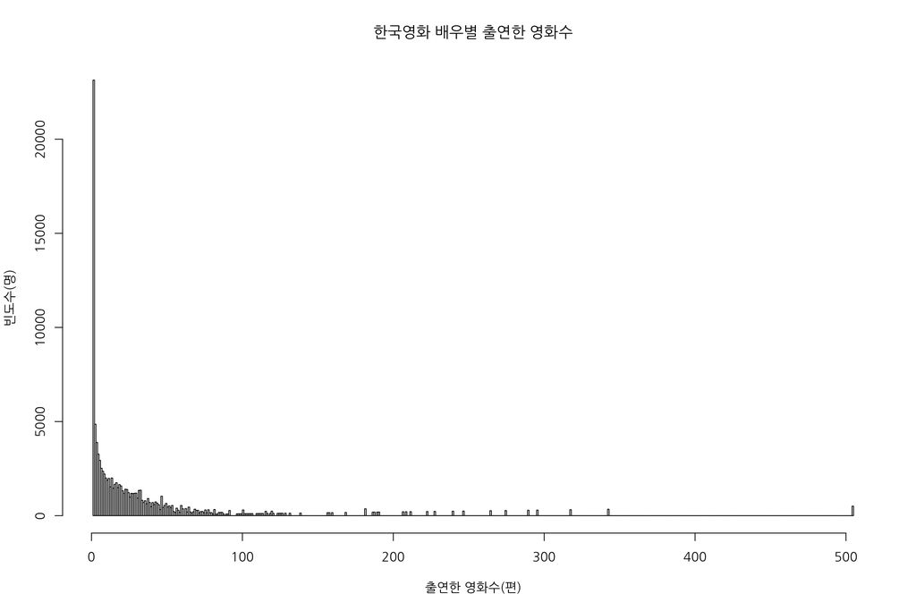

```r
# R 기본 함수로 히스토그램을 그려봅니다.
hist(x = wdf$movieCnt,
     breaks = 1:505, col = 'white', border = 'black',
     xlab = '출연한 영화수(편)', ylab = '빈도수(명)',
     main = '한국영화 배우별 출연한 영화수')
```

```r
# ggplot을 이용하여 위와 비슷한 히스토그램을 그리려면
# 아래 코드를 실행하면 됩니다.
ggplot(data = wdf, aes(x = movieCnt)) +
  geom_histogram(breaks = 1:505, color = 'black', fill = 'white') +
  labs(x = '출연한 영화수(편)', y = '빈도수(명)') +
  ggtitle(label = '한국영화 배우별 출연한 영화수')
```

```r
# 배우별 영화 출연 횟수 데이터로 도수분포표를 만듭니다.

# 먼저 최소값과 최대값을 확인합니다.
range(wdf$movieCnt)
```

```
## [1]   1 505
```

```r
# 최대값이 505였으므로 0부터 505까지 5단위로 계급을 설정합니다.
cuts <- seq(from = 0, to = 505, by = 5)

# 이제 각 계급별 빈도수를 구합니다.
mvCntTbl <- wdf %>%
  select(c('acode', 'movieCnt')) %>%
  na.omit() %>%
  unique() %>%
  select('movieCnt') %>%
  data.matrix() %>%
  Hmisc::cut2(cuts = cuts, minmax = TRUE) %>%
  table()

# 각 구간별 상대도수를 구한 후, 도수분포표에 추가합니다.
propTbl <- prop.table(mvCntTbl)
mvCntTbl <- rbind(mvCntTbl, propTbl)

# 각 구간별 누적상대도수를 구한 후, 도수분포표에 추가합니다.
csumTbl <- cumsum(propTbl)
mvCntTbl <- rbind(mvCntTbl, csumTbl)

# 행별 합계를 구한 후, 도수분포표에 추가합니다.
mvCntTbl <- addmargins(A = mvCntTbl, margin = 2)

# 소수점 2째자리에서 반올림합니다.
mvCntTbl <- round(x = mvCntTbl, digits = 2)

# 행 이름을 변경합니다.
rownames(mvCntTbl) <- c('빈도수(명)', '상대도수(%)', '누적상대도수(%)')

# 도수분포표를 출력합니다.
print(mvCntTbl)
```

```
##                 [  0,  5) [  5, 10) [ 10, 15) [ 15, 20) [ 20, 25)
## 빈도수(명)       22345.00   2045.00    797.00    474.00    315.00
## 상대도수(%)          0.83      0.08      0.03      0.02      0.01
## 누적상대도수(%)      0.83      0.91      0.94      0.96      0.97
##                 [ 25, 30) [ 30, 35) [ 35, 40) [ 40, 45) [ 45, 50)
## 빈도수(명)         214.00    177.00    101.00     75.00     62.00
## 상대도수(%)          0.01      0.01      0.00      0.00      0.00
## 누적상대도수(%)      0.98      0.98      0.99      0.99      0.99
##                 [ 50, 55) [ 55, 60) [ 60, 65) [ 65, 70) [ 70, 75)
## 빈도수(명)          50.00     22.00        24        20        16
## 상대도수(%)          0.00      0.00         0         0         0
## 누적상대도수(%)      0.99      0.99         1         1         1
##                 [ 75, 80) [ 80, 85) [ 85, 90) [ 90, 95) [ 95,100)
## 빈도수(명)             14         9         7         5         3
## 상대도수(%)             0         0         0         0         0
## 누적상대도수(%)         1         1         1         1         1
##                 [100,105) [105,110) [110,115) [115,120) [120,125)
## 빈도수(명)              7         3         5         4         4
## 상대도수(%)             0         0         0         0         0
## 누적상대도수(%)         1         1         1         1         1
##                 [125,130) [130,135) [135,140) 140 145 150 [155,160) 160
## 빈도수(명)              4         1         1   0   0   0         2   1
## 상대도수(%)             0         0         0   0   0   0         0   0
## 누적상대도수(%)         1         1         1   1   1   1         1   1
##                 [165,170) 170 175 [180,185) [185,190) [190,195) 195 200
## 빈도수(명)              1   0   0         2         2         2   0   0
## 상대도수(%)             0   0   0         0         0         0   0   0
## 누적상대도수(%)         1   1   1         1         1         1   1   1
##                 [205,210) [210,215) 215 [220,225) [225,230) 230 235 240
## 빈도수(명)              2         1   0         1         1   0   0   1
## 상대도수(%)             0         0   0         0         0   0   0   0
## 누적상대도수(%)         1         1   1         1         1   1   1   1
##                 [245,250) 250 255 260 265 270 275 280 285 290 [295,300)
## 빈도수(명)              1   0   0   0   1   0   1   0   0   1         1
## 상대도수(%)             0   0   0   0   0   0   0   0   0   0         0
## 누적상대도수(%)         1   1   1   1   1   1   1   1   1   1         1
##                 300 305 310 [315,320) 320 325 330 335 [340,345) 345 350
## 빈도수(명)        0   0   0         1   0   0   0   0         1   0   0
## 상대도수(%)       0   0   0         0   0   0   0   0         0   0   0
## 누적상대도수(%)   1   1   1         1   1   1   1   1         1   1   1
##                 355 360 365 370 375 380 385 390 395 400 405 410 415 420
## 빈도수(명)        0   0   0   0   0   0   0   0   0   0   0   0   0   0
## 상대도수(%)       0   0   0   0   0   0   0   0   0   0   0   0   0   0
## 누적상대도수(%)   1   1   1   1   1   1   1   1   1   1   1   1   1   1
##                 425 430 435 440 445 450 455 460 465 470 475 480 485 490
## 빈도수(명)        0   0   0   0   0   0   0   0   0   0   0   0   0   0
## 상대도수(%)       0   0   0   0   0   0   0   0   0   0   0   0   0   0
## 누적상대도수(%)   1   1   1   1   1   1   1   1   1   1   1   1   1   1
##                 495 [500,505]      Sum
## 빈도수(명)        0         1 26828.00
## 상대도수(%)       0         0     1.00
## 누적상대도수(%)   1         1   100.47
```

5편 미만 출연한 영화배우가 전체 26828명 중 83%를 차지하고 있습니다. 나중에 데이터 프레임을 행렬로 변환할 때 이들을 다 포함시키면 계산이 매우 느려집니다. 따라서 행렬을 축소하기 위해 이들을 제거해야 합니다.

### 2-5. **영화-배우 행렬** 만들기

같은 영화에 함께 출연한 배우 데이터를 만들기 위해 먼저 **영화-배우 행렬**을 만든 후, 전치한 행렬과의 행렬곱 연산을 통해 **배우-배우 행렬**을 만듭니다. 방금 언급한 바와 같이 행렬의 차원이 크면 연산에 많은 시간이 소요되므로, 출연 배우수가 2명 이상인 영화 및 출연 영화수가 5편 이상인 배우만 남긴 후 **영화-배우 행렬**로 변환합니다. 이 때 행렬의 원소로 사용될 컬럼을 신규로 생성합니다. 이 컬럼은 “해당 영화에 출연했다”는 것을 의미합니다.

```r
# 영화-배우 행렬을 만듭니다.
# [주의] dplyr의 filter()가 먼저 불려온 stats의 filter()와 충돌합니다!
wdf2Mat <- wdf %>%
  select(c('mcode', 'acode', 'actorCnt', 'movieCnt')) %>%
  na.omit() %>%
  dplyr::filter(actorCnt >= 2 & movieCnt >= 5) %>%
  select(c('mcode', 'acode')) %>%
  mutate(check = 1) %>%
  acast(formula = mcode ~ acode, fill = 0)
# 행렬의 차원수를 확인합니다.
dim(wdf2Mat)
```

```
## [1] 13524  4482
```

```r
# 미리보기 합니다.
wdf2Mat[11:20, 11:20]
```

```
##        102207 102416 102494 102521 102523 102559 10319 10320 103201 103287
## 100042      0      0      0      0      0      0     0     0      0      0
## 100055      0      0      0      0      0      0     0     0      0      0
## 100057      0      0      0      0      0      0     0     0      0      0
## 100165      0      0      0      0      0      0     0     0      0      0
## 100215      0      0      0      0      0      0     0     0      0      0
## 100304      0      0      0      0      0      0     0     0      0      0
## 100306      0      0      0      0      0      0     0     0      0      0
## 100318      0      0      0      0      0      0     0     0      0      0
## 100337      0      0      0      0      0      0     0     0      0      0
## 100354      0      0      0      0      0      0     0     0      0      0
```

행렬의 열 이름이 영화배우 코드로 되어 있어서 누군지 알 수 없습니다. 따라서 열 이름을 영화배우 이름으로 대체하는 편이 좋습니다. 하지만 영화배우 이름은 중복이 꽤 많을 것으로 추정되므로, 먼저 이름으로 중복되는 규모를 확인한 후, 중복되는 영화배우 이름은 `홍길동-1, 홍길동-2, ...`와 같이 변형해보겠습니다.

```r
# 새로 만든 행렬에 속한 영화배우 이름만 따로 추출합니다.
actorName <- wdf %>%
  select(c('acode', 'aname', 'movieCnt')) %>%
  unique() %>%
  dplyr::filter(acode %in% colnames(wdf2Mat)) %>%
  arrange(aname, desc(movieCnt))

# 이름으로 중복되는 규모를 확인합니다.
# 총 4482명 중 283명이 중복되는 것을 확인할 수 있습니다.
actorName %>%
  select('aname') %>%
  duplicated() %>%
  sum()
```

```
## [1] 283
```

```r
# 중복된 영화배우 이름을 변형합니다.
actorName <- transform(`_data` = actorName,
                       anameNew = ifelse(
                         test = (duplicated(aname) | duplicated(aname, fromLast = TRUE)),
                         yes = paste(aname, ave(aname, aname, FUN = seq_along), sep = '-'),
                         no = aname
                         )
                       )

# 변형된 부분을 확인합니다.
actorName[c(78:82, 116:120), ]
```

```
##      acode  aname movieCnt anameNew
## 78    6806 강예원       20   강예원
## 79   43522 강용규        6   강용규
## 80  119949 강용석       10 강용석-1
## 81  318195 강용석        9 강용석-2
## 82   51640 강유미        9   강유미
## 116 140581 강하늘       24   강하늘
## 117 220115 강한나       11 강한나-1
## 118 388701 강한나        6 강한나-2
## 119 127285 강한별        6   강한별
## 120 116133 강해인        5   강해인
```

행렬의 열 이름을 새로 만든 이름으로 변경하기에 앞서 현재 열 이름(배우코드)의 순서와 새로 만든 데이터 프레임의 배우코드 순서가 맞는지 확인해야 합니다. 행렬의 열 이름은 오름차순으로 되어 있으므로, 새로 만든 데이터 프레임을 배우코드 기준으로 오름차순 정렬한 후 두 벡터가 서로 다른 부분이 있는지 확인합니다.

```r
# 배우코드 기준으로 오름차순 정렬합니다.
actorName <- actorName[order(actorName$acode, decreasing = FALSE), ]

# 두 벡터가 서로 다른 부분 부분이 있는지 확인합니다.
which(colnames(wdf2Mat) != actorName$acode)
```

```
## integer(0)
```

```r
# 두 벡터가 순서까지 같으므로, 행렬의 열 이름을 변경합니다.
colnames(wdf2Mat) <- actorName$anameNew
```

### 2-6. **배우-배우 행렬** 만들기

이렇게 만든 **배우-배우 행렬**은 대칭행렬입니다. 대각원소는 해당 배우가 출연한 전체 영화수로 이번 프로젝트에서는 의미가 없으므로 0으로 치환합니다. 아울러 나중에 네트워크 객체를 만들 때 배우 간 연결(link) 건이 중복되므로 상삼각원소도 모두 0으로 바꿔야 합니다.

```r
# 같은 영화에 출연한 횟수를 원소로 갖는 행렬을 생성합니다.
# [주의] 행렬의 차원수에 따라 이 연산과정이 가장 크게 영향을 받습니다.
actorsMat <- t(wdf2Mat) %*% wdf2Mat

# 행렬의 차원수를 확인합니다.
dim(actorsMat)
```

```
## [1] 4482 4482
```

```r
# 미리보기 합니다.
actorsMat[11:20, 11:20]
```

```
##        오산하 붐 안신우 임주환 최찬숙 김재중 이휘재 조희봉 보아 김혜미
## 오산하      6  0      0      0      0      0      0      0    0      0
## 붐          0 12      0      0      0      0      2      0    1      0
## 안신우      0  0      8      0      0      0      0      0    0      0
## 임주환      0  0      0     17      0      0      0      0    0      0
## 최찬숙      0  0      0      0      9      0      0      0    0      0
## 김재중      0  0      0      0      0      9      0      0    0      0
## 이휘재      0  2      0      0      0      0     37      0    0      0
## 조희봉      0  0      0      0      0      0      0     64    1      0
## 보아        0  1      0      0      0      0      0      1   11      0
## 김혜미      0  0      0      0      0      0      0      0    0      6
```

```r
# 같은 영화에 출연한 적이 있으면 1, 없으면 0을 갖도록 2 이상인 값을 1로 치환합니다.
actorsMat <- ifelse(test = (actorsMat >= 2), yes = 1, no = 0)

# 대각원소와 상삼각원소를 0으로 치환하여 하삼각행렬만 값을 갖도록 합니다.
actorsMat[upper.tri(x = actorsMat, diag = TRUE)] <- 0

# 미리보기 합니다.
actorsMat[11:20, 11:20]
```

```
##        오산하 붐 안신우 임주환 최찬숙 김재중 이휘재 조희봉 보아 김혜미
## 오산하      0  0      0      0      0      0      0      0    0      0
## 붐          0  0      0      0      0      0      0      0    0      0
## 안신우      0  0      0      0      0      0      0      0    0      0
## 임주환      0  0      0      0      0      0      0      0    0      0
## 최찬숙      0  0      0      0      0      0      0      0    0      0
## 김재중      0  0      0      0      0      0      0      0    0      0
## 이휘재      0  1      0      0      0      0      0      0    0      0
## 조희봉      0  0      0      0      0      0      0      0    0      0
## 보아        0  0      0      0      0      0      0      0    0      0
## 김혜미      0  0      0      0      0      0      0      0    0      0
```

마지막으로 행의 합이 0인 행의 위치를 찾아 삭제합니다.

```r
# 행의 합이 0인 행의 위치를 탐색합니다.
zeroLocs <- actorsMat %>%
  purrr::when(rowSums(.) == 0) %>%
  which() %>%
  as.numeric()

# 해당 행을 삭제합니다.
actorsMat <- actorsMat[-zeroLocs, ]

# 행렬의 차원수를 확인합니다.
dim(actorsMat)
```

```
## [1] 3376 4482
```

```r
# 미리보기 합니다.
actorsMat[11:20, 11:20]
```

```
##          오산하 붐 안신우 임주환 최찬숙 김재중 이휘재 조희봉 보아 김혜미
## 김미희        0  0      0      0      0      0      0      0    0      0
## 최명경        0  0      0      0      0      0      0      0    0      0
## 최귀화        0  0      0      0      0      0      0      1    0      0
## 박진영-1      0  0      0      0      0      0      0      0    1      0
## 황정민-1      0  0      0      0      0      0      0      1    0      0
## 서현진        0  0      0      0      0      1      0      0    0      0
## 조영진        0  0      0      0      0      0      0      1    0      0
## 구봉서        0  0      0      0      0      0      0      0    0      0
## 김국진        0  0      0      0      0      0      0      0    0      0
## 원석연        0  0      0      0      0      0      0      0    0      0
```

## 3단계 : 한국판 Kevin Bacon을 찾습니다.

1. 함께 출연한 배우 집합을 만들기 위해 **배우-배우 행렬**에서 원소의 값이 1인 열 번호만 리스트 자료형으로 수집합니다.
2. 각 행별로 순환 실행하면서 앞서 수집한 위치에 해당하는 **배우-배우 행렬**의 행 이름과 열 이름을 각각 `from`과 `to` 컬럼에 저장한 데이터 프레임을 생성합니다.
3. 이 데이터 프레임으로 방향성이 없는 무향 **graph 객체**를 생성한 후, 각 배우별 최단거리를 구합니다. 최단거리는 `0`과 `Inf` 사이의 값을 갖는데, `0`은 자기자신이며, `Inf`은 서로 연결고리가 없다는 것을 의미합니다. 연결고리가 없는 경우 `99`를 강제 할당합니다.
4. 네트워크 시각화 예제로 1번 꼭지점(이휘재)에 연결된 꼭지점들(배우들)과 연결고리들을 추출한 후, 간단한 네트워크 그래프를 그려봅니다.
5. 마지막으로 각 배우별 최단거리의 평균을 계산합니다. 이 값이 가장 작은 배우를 한국판 Kevin Bacon으로 지정합니다.

### 3-1. **배우-배우 행렬**에서 원소가 1인 열 번호 수집 (리스트)

```r
# 필요 패키지 불러오기
library(igraph)
```

```r
# 결과를 저장할 빈 리스트 객체를 생성합니다.
ones <- list()

# 배우-배우 행렬의 원소가 1인 열 번호만 수집합니다.
for (i in 1:nrow(actorsMat)) {
  ones[[i]] <- which(actorsMat[i, ] == 1) %>% as.numeric()
}

# 1~10번 행에서 원소가 1인 열 번호를 확인합니다.
ones[1:10]
```

```
## [[1]]
## [1] 12
##
## [[2]]
## [1] 18
##
## [[3]]
## [1] 17
##
## [[4]]
## [1] 18
##
## [[5]]
## [1] 21
##
## [[6]]
## [1] 21 56
##
## [[7]]
## [1] 71
##
## [[8]]
## [1] 18 21 44 69
##
## [[9]]
## [1] 31 73
##
## [[10]]
## [1] 41
```

### 3-2. 함께 출연한 배우 이름 집합 만들기 (데이터 프레임)

```r
# 결과를 저장할 빈 데이터 프레임 객체를 생성합니다.
actorsWdf <- data.frame()

# 행별 함께 출연한 적 있는 행 번호와 열 번호를 수집합니다.
# 열 번호가 여러 개일 경우, 데이터 프레임에 행으로 추가됩니다.
for (i in 1:length(ones)) {
  codf <- data.frame(from = rownames(actorsMat)[i],
                     to = colnames(actorsMat)[ones[[i]]])
  actorsWdf <- rbind(actorsWdf, codf)
}

# 중복 건이 있는지 확인합니다.
actorsWdf[duplicated(actorsWdf), ]
```

```
## [1] from to
## <0 rows> (or 0-length row.names)
```

```r
# 데이터 프레임의 차원수를 확인합니다.
dim(actorsWdf)
```

```
## [1] 47492     2
```

### 3-3. **graph 객체** 생성하고 각 배우별 최단거리 계산

```r
# 방향성이 없는 무향 graph 객체를 생성합니다.
graphObj <- graph_from_data_frame(d = actorsWdf, directed = FALSE)

# graph 객체를 출력하여 구조를 파악합니다.
print(graphObj)
```

```
## IGRAPH 4cf7992 UN-- 3961 47492 --
## + attr: name (v/c)
## + edges from 4cf7992 (vertex names):
##  [1] 이휘재  --붐     장항선  --조희봉 이휘재  --김숙   유인나  --조희봉
##  [5] 장항선  --서영진 장항선  --서상익 서영진  --서상익 서상익  --강민호
##  [9] 전노민  --조희봉 장항선  --전노민 전노민  --지창욱 전노민  --이채영
## [13] 진세연  --성혁   전노민  --진세연 남보라  --송재희 김미희  --이승민
## [17] 최명경  --윤희석 최귀화  --조희봉 최귀화  --황건-2 박진영-1--보아
## [21] 황정민-1--조희봉 황정민-1--이희준 서현진  --김재중 조영진  --조희봉
## [25] 구봉서  --도금봉 김국진  --주상욱 장항선  --원석연 서영진  --원석연
## [29] 강해인  --박보영 정원중  --조희봉 전노민  --정원중 남보라  --정원중
## + ... omitted several edges
```

```r
# 각 배우별로 나머지 배우들(3960명)과의 최단거리를 계산합니다.
shortPath <- shortest.paths(graphObj)

# 최단거리 행렬의 차원수를 확인합니다.
dim(shortPath)
```

```
## [1] 3961 3961
```

```r
# 최단거리 행렬을 미리보기 합니다.
shortPath[1:10, 1:10]
```

```
##        이휘재 장항선 김숙 유인나 서영진 서상익 강민호 전노민 진세연 남보라
## 이휘재      0      3    1      3      3      3      3      2      3      3
## 장항선      3      0    3      2      1      1      2      1      2      2
## 김숙        1      3    0      4      3      4      3      3      3      3
## 유인나      3      2    4      0      3      3      3      2      3      3
## 서영진      3      1    3      3      0      1      2      2      3      3
## 서상익      3      1    4      3      1      0      1      2      3      3
## 강민호      3      2    3      3      2      1      0      2      3      3
## 전노민      2      1    3      2      2      2      2      0      1      2
## 진세연      3      2    3      3      3      3      3      1      0      2
## 남보라      3      2    3      3      3      3      3      2      2      0
```

최단거리 행렬에 있는 각 원소값은 두 배우 간 최단거리를 의미합니다. `1`은 같은 영화에 출연한 적이 있다는 것입니다. `2`는 같은 영화에 출연한 배우들과 다른 영화에 출연한 적이 있을 때 적용됩니다. 이휘재와 김숙의 최단거리는 1이며, 이휘재와 전노민의 최단거리는 2입니다.

```r
# 최단거리 행렬의 최소값과 최대값을 확인합니다.
# 자기 자신은 0, 서로 연결고리가 없으면 Inf 값을 가집니다.
range(shortPath)
```

```
## [1]   0 Inf
```

```r
# Inf 값을 제외하고는 최대값을 확인합니다. 14가 가장 큽니다.
range(shortPath, finite = TRUE)
```

```
## [1]  0 14
```

```r
# 서로 연결고리가 없는 배우 간 거리를 99로 치환합니다.
# 만약 NA로 변경하면 오히려 평균이 짧아질 수 있으므로 주의합니다!
shortPath <- ifelse(test = (shortPath == Inf), yes = 99, no = shortPath)
```

### 3-4. 네트워크 시각화 예제

`graph 객체`로 전체 네트워크 그래프를 그리면 온통 까맣게 보여집니다. 따라서 필요한 부분만 추출하여 시각화할 수 있습니다. 이번 예제에서는 1번 꼭지점에 해당하는 배우(이휘재)와 연결된 다른 배우들 데이터를 추출하여 간단한 네트워크 그래프를 그려보겠습니다.

```r
# 1번 꼭지점(이휘재)과 직접 연결된, 즉 최단거리가 1인 배우(들)을 추출합니다.
# 총 19명이 직접 연결되어 있습니다.
vrtis1 <- shortPath['이휘재', ] %>%
  purrr::when(. == 1) %>%
  which() %>%
  names()

print(vrtis1)
```

```
##  [1] "김숙"     "김준현"   "지상렬"   "한고은"   "안선영-1" "차인표"
##  [7] "김우빈"   "은지원"   "성시경"   "현영"     "박미선"   "김신영"
## [13] "이경실-1" "구본승"   "정형돈"   "이혁재"   "택연"     "권오중"
## [19] "붐"
```

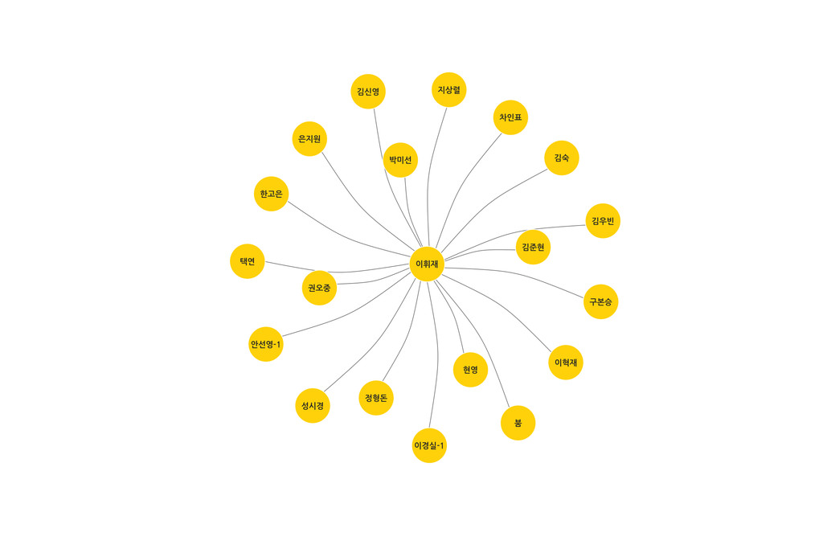

```r
# 이휘재(1번 꼭지점)와 직접 연결된 네트워크 그래프 그려보기
# 대괄호 안에 `%--%` 기호 왼쪽은 from, 오른쪽은 to의 꼭지점 위치를 지정합니다.
# 아니면 '이휘재'처럼 꼭지점 이름을 직접 입력해도 됩니다.
# V(graphObj)는 전체 꼭지점(vertices)을 출력합니다.
# E(graphObj)는 전체 연결고리(edge)를 출력합니다.
edges <- E(graphObj)[1%--%V(graphObj)]

# 위에서 이휘재와 직접 연결된 꼭지점들과의 연결고리만 지정한 후,
# 아래 명령을 통해 해당 연결고리만 포함한 subgraph 객체를 추출할 수 있습니다.
graphPlt1 <- subgraph.edges(graph = graphObj, eids = edges) %>%
  simplify(remove.multiple = TRUE, remove.loops = TRUE)

# 네트워크 그래프를 그립니다.
plot(x = graphPlt1,
     vertex.color = 'gold',
     vertex.frame.color = 'white',
     vertex.shape = "circle",
     vertex.size = 20,
     #vertex.label = NULL,
     vertex.label.color = "gray20",
     vertex.label.family = 'NanumGothic',
     vertex.label.font = 2,
     vertex.label.cex = 0.7,
     #vertex.label.dist = 1,
     #vertex.label.degree = 0,
     edge.color = "gray50",
     edge.width = 0.8,
     #edge.lty = 1,
     edge.curved = 0.2,
     margin = c(0,0,0,0)
     )
```

이번에는 이휘재와 전노민 사이에 연결된 꼭지점들로 추출하여 확대된 네트워크 그래프를 그려보겠습니다.

```r
# 이휘재와 직접 연결된 배우들 중 전노민과 직접 연결된 배우(들)을 확인합니다.
# 19명 중 3명이 전노민과 함께 영화에 출연한 적이 있습니다.
vrtis2 <- shortPath[vrtis1, '전노민'] %>%
  purrr::when(. == 1) %>%
  which() %>%
  names()

print(vrtis2)
```

```
## [1] "차인표"   "이경실-1" "권오중"
```

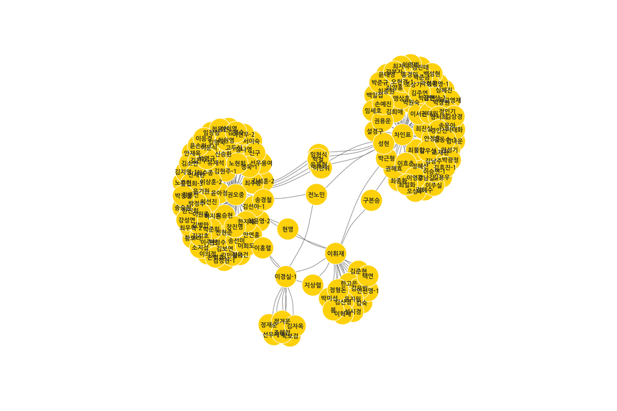

```r
# 이제 from 위치에 이휘재와 새로 추출한 3명을 넣고, 연결고리를 추출하겠습니다.
edges <- E(graphObj)[c('이휘재', vrtis2)%--%V(graphObj)]

# 위 연결고리에 해당하는 subgraph 객체를 생성합니다.
graphPlt2 <- subgraph.edges(graph = graphObj, eids = edges) %>%
  simplify(remove.multiple = TRUE, remove.loops = TRUE)

# 네트워크 그래프를 그려봅니다.
plot(x = graphPlt2,
     vertex.color = 'gold',
     vertex.frame.color = 'white',
     vertex.shape = "circle",
     vertex.size = 16,
     #vertex.label = NULL,
     vertex.label.color = "gray20",
     vertex.label.family = 'NanumGothic',
     vertex.label.font = 2,
     vertex.label.cex = 0.7,
     #vertex.label.dist = 1,
     #vertex.label.degree = 0,
     edge.color = "gray50",
     edge.width = 0.8,
     #edge.lty = 1,
     edge.curved = 0.2,
     margin = c(0,0,0,0)
     )
```

차인표, 권오중 등 더 전문적인 배우들과 직접 연결된 배우들이 훨씬 많다보니 첫 번째 네트워크에 비해 상당히 커졌습니다. 이 정도로만 커져도 시각화하기가 쉽지 않습니다.

### 3-5. 최단거리 평균을 구하고, 한국판 Kevin Bacon 찾기!

```r
# 행 기준으로 최단거리의 평균을 계산합니다.
pathMean <- data.frame(mean = rowMeans(x = shortPath, na.rm = TRUE))

# 새로 생성된 데이터 프레임의 행 이름에 배우 이름이 입력되어 있습니다.
# 행 이름을 추축하여 데이터 프레임의 컬럼으로 추가합니다.
pathMean$anameNew <- rownames(pathMean)

# 행 이름을 초기화합니다.
rownames(pathMean) <- c()

# 영화배우 정보 데이터셋과 병합합니다.
resultKoKB <- merge(x = actorName,
                    y = pathMean,
                    by = 'anameNew',
                    all.Y = TRUE)

# 최단거리 평균을 기준으로 오름차순 정렬합니다.
resultKoKB <- resultKoKB[order(resultKoKB$mean, decreasing = FALSE), ]

# 최단거리 평균이 가장 짧은 상위 20명의 영화배우 목록을 확인합니다.
head(x = resultKoKB, n = 20L)
```

```
##      anameNew acode  aname movieCnt     mean
## 2541   이순재  7137 이순재      207 3.822267
## 1186   박근형  3213 박근형      190 3.825549
## 2820   이한위  8775 이한위       99 3.888160
## 770  김지영-1 19005 김지영      113 3.894219
## 3502   천호진  2009 천호진       90 3.901035
## 2695   이정길  6686 이정길      119 3.915425
## 853    김해숙 12015 김해숙       92 3.921232
## 262    김갑수  1706 김갑수       78 3.939409
## 1521   변희봉  9055 변희봉       80 3.941681
## 2329 이경영-1  2518 이경영      106 3.949760
## 3800   한진희  2033 한진희      111 3.950265
## 1750   송재호  1829 송재호      101 3.952032
## 3257   정혜선 11686 정혜선      124 3.954052
## 1320   박인환  1799 박인환       86 3.958849
## 1307   박원숙  1797 박원숙      107 3.960868
## 3114   정동환  7238 정동환       91 3.967432
## 303    김규철  6785 김규철       63 3.969452
## 595  김영애-1  1740 김영애      125 3.972229
## 1740   송옥숙  2339 송옥숙       68 3.981570
## 597    김영옥  2119 김영옥       98 3.985610
```

한국판 Kevin Bacon은 이순재씨로 판명되었습니다. 사실 이번 프로젝트에 사용된 데이터가 한국영화와 한국드라마가 모두 포함된 것이라 이런 결과가 나왔습니다. 아마 영화만 따로 추출하여 작업했다면 이와는 사뭇 다른 결과가 나왔을 것입니다. 아무튼 한국판 Kevin Bacon으로 선정되신 이순재씨 축하합니다!!

## 끝!

[^1]: 더 자세한 내용은 [위키백과 Kevin Bacon의 여섯 다리](https://ko.wikipedia.org/wiki/%EC%BC%80%EB%B9%88_%EB%B2%A0%EC%9D%B4%EC%BB%A8%EC%9D%98_%EC%97%AC%EC%84%AF_%EB%8B%A4%EB%A6%AC)를 참조하세요
[^2]: 여기에서 [웹크롤러](https://github.com/MrKevinNa/SixDegreesOfKoreanActors/blob/master/naver%20movie%20crawler_v1.1.R)를 내려받으세요.
[^3]: 여기에서 [데이터셋](https://github.com/MrKevinNa/SixDegreesOfKoreanActors/tree/master/data)을 내려받으세요.